# Part II - (Ford GoBike System Data (January - April, 2019))

## by (Umar Abubakar)

## Investigation Overview

> The investigation of Ford GoBike System Data was focused on the duration of rides and those features such as distance that affect the duration of rides and different periods (time of day, day of the week, and month) that most rides are taken by different groups of users.

## Dataset Overview

> The original dataset provided contained rides taken during the month of February 2019. Effort was made to gather additional data for the remaining months of 2019. Due to Ford GoBike website being offline and other repositories not having data for the months of May and beyond, we were only able to gather additional data for the months of January, March and April of 2019 bringing the number of months of data to four (4). Additional data was gathered from (https://s3.amazonaws.com/fordgobike-data/index.html).

> The dataset contains 870904 rides taken during the months of January to April of 2019 with 16 attributes namely: (duration_sec, start_time, end_time, start_station_id, start_station_name, start_station_latitude, start_station_longitude, end_station_id, end_station_name, end_station_latitude, end_station_longitude, bike_id, user_type, member_birth_year, member_gender, bike_share_for_all_trip)

## Duration and Distance of Rides from January to April

- The duration of rides declined between January and February after which the duration of rides increased from February to April.
- Distance followed a similar trend as duration with a minor difference. Distance only increased from February to March followed by a sharp decrease between March and April.

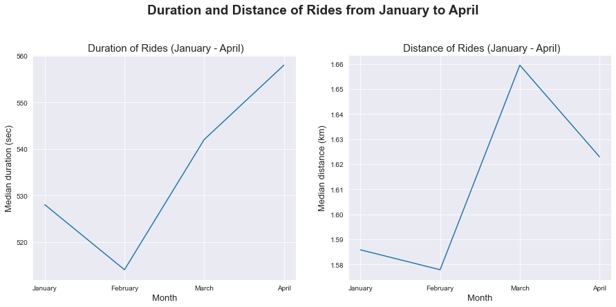

## Proportion and Duration of Rides by User Type and Gender Type

- The plots show that most of the rides are taken by males and that Females and Other (unspecified gender) take the trips with the longest duration despite the percentage of male members being larger.
- Despite the percentage of rides taken by subscribers being larger than those taken by customers, customers take trips with longer duration than subscribers.

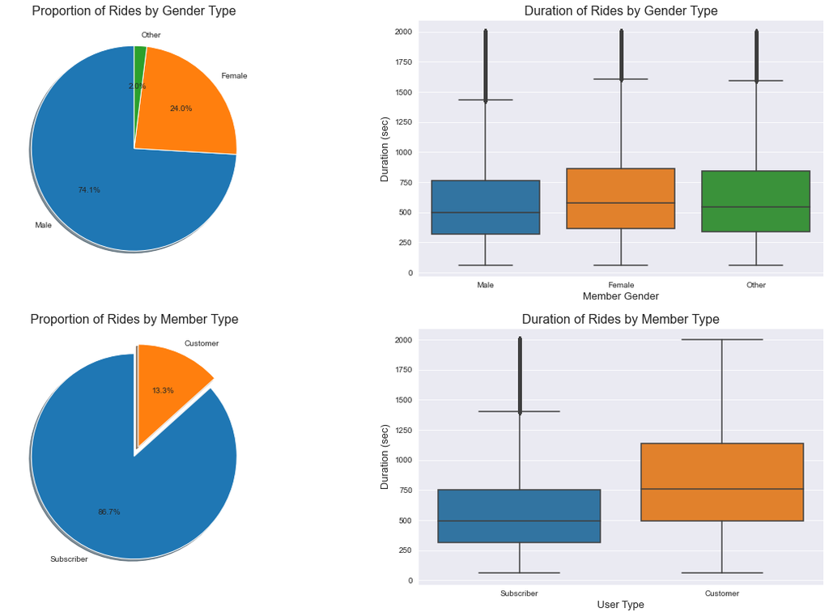

## Duration of Rides by User Type at Different Periods

- Between Ford GoBike customers and subscribers, customers tend to take the longest rides at all times of the day, on all days of the week.
- A similar trend for the duration of rides per month was also observed.

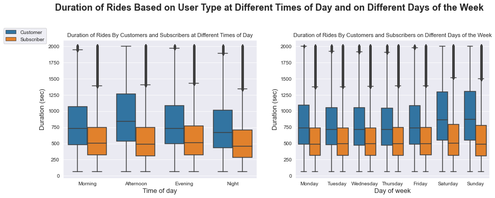

## Duration of Rides by Gender Type at Different Periods

- Between Males, Females, and Other (Unspecified gender), females take the longest rides followed by Other and Males at all times of day, on all days of the week. Males take rides with the shortest durations.
- A similar trend for the duration of rides per month was also observed.

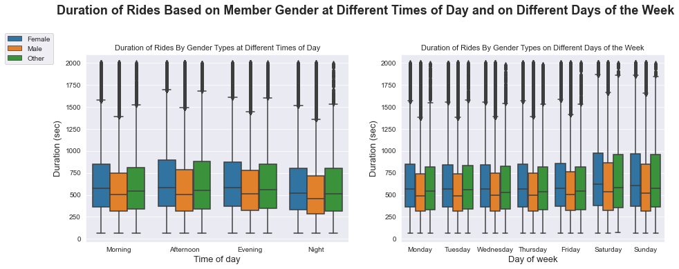

## Distance vs. Duration of Rides Between Gender Types

- The plots show that there is a similar trend for all gender types for Ford GoBike members and that the number of males taking short distance rides is larger than that of females and Other (unspecified gender).

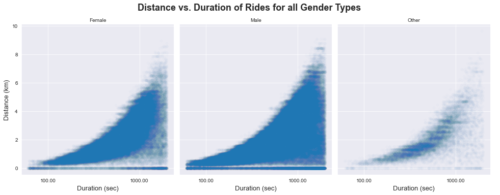